# Trabajo Práctico Nº 3: Regresión logística

Análisis de ingresos altos en el Adult Census Income Dataset

Autor/a

Juan Ignacio Gutierrez Julian

Fecha de publicación

20 de junio de 2026

**Nota**

**Objetivo del trabajo**

Este trabajo práctico analiza qué variables sociodemográficas y laborales se asocian con la probabilidad de que una persona tenga ingresos anuales superiores a **$50.000 dólares** en el dataset `adult_census_USA.csv`. Para ello, se trabajará con una regresión logística binomial, tomando como variable dependiente `income`, que distingue entre personas con ingresos `<=50K` y personas con ingresos `>50K`.

# Preparación, carga y limpieza inicial de datos

## Carga de paquetes

```r
# Instalo pacman, para cargar todos los paquetes necesarios de forma ordenada.
if (!require("pacman")) install.packages("pacman")

pacman::p_load(
  tidyverse,
  here,
  janitor,
  broom,
  modelsummary,
  marginaleffects,
  scales,
  kableExtra
)
```

## Carga de la base de datos cruda

```r
# Cargo la base original desde la carpeta TP3/data.
datos_raw <- read_csv(here("TP3", "data", "adult_census_USA.csv"))

# Reviso dimensiones generales de la base original.
dim(datos_raw)
```

```
[1] 15766    14
```

```r
# Reviso los nombres originales de las variables.
names(datos_raw)
```

```
 [1] "age"            "workclass"      "education"      "education_num"
 [5] "marital_status" "occupation"     "relationship"   "race"
 [9] "sex"            "capital_gain"   "capital_loss"   "hours_per_week"
[13] "native_country" "income"
```

```r
# Reviso la estructura general de la base.
glimpse(datos_raw)
```

```
Rows: 15,766
Columns: 14
$ age            <dbl> 28, 37, 49, 52, 31, 42, 37, 30, 38, 43, 40, 35, 43, 56,…
$ workclass      <chr> "Private", "Private", "Private", "Self-emp-not-inc", "P…
$ education      <chr> "Bachelors", "Masters", "9th", "HS-grad", "Masters", "B…
$ education_num  <dbl> 13, 14, 5, 9, 14, 13, 10, 13, 7, 14, 16, 5, 7, 13, 9, 1…
$ marital_status <chr> "Married-civ-spouse", "Married-civ-spouse", "Married-sp…
$ occupation     <chr> "Prof-specialty", "Exec-managerial", "Other-service", "…
$ relationship   <chr> "Wife", "Wife", "Not-in-family", "Husband", "Not-in-fam…
$ race           <chr> "Black", "White", "Black", "White", "White", "White", "…
$ sex            <chr> "Female", "Female", "Female", "Male", "Female", "Male",…
$ capital_gain   <dbl> 0, 0, 0, 0, 14084, 5178, 0, 0, 0, 0, 0, 0, 0, 0, 0, 0, …
$ capital_loss   <dbl> 0, 0, 0, 0, 0, 0, 0, 0, 0, 0, 0, 0, 2042, 0, 0, 0, 0, 0…
$ hours_per_week <dbl> 40, 40, 16, 45, 50, 40, 80, 40, 50, 45, 60, 40, 40, 40,…
$ native_country <chr> "Cuba", "United-States", "Jamaica", "United-States", "U…
$ income         <chr> "<=50K", "<=50K", "<=50K", ">50K", ">50K", ">50K", ">50…
```

## Normalización de nombres y revisión inicial

```r
# Creo una primera versión de la base con nombres normalizados.
datos_base <- datos_raw |>
  clean_names()

# Reviso cómo quedaron los nombres después de la limpieza.
names(datos_base)
```

```
 [1] "age"            "workclass"      "education"      "education_num"
 [5] "marital_status" "occupation"     "relationship"   "race"
 [9] "sex"            "capital_gain"   "capital_loss"   "hours_per_week"
[13] "native_country" "income"
```

## Limpieza inicial de variables de texto

```r
# Antes de transformar income, reviso sus valores originales.
datos_base |>
  count(income, sort = TRUE)
```

| income | n |
| --- | --- |
| <=50K | 8258 |
| >50K | 7508 |

```r
# Creo la base inicial
datos <- datos_base |>

  # Limpio espacios innecesarios en todas las variables de texto.
  # También convierto los signos "?" en valores perdidos
  mutate(
    across(where(is.character), ~ na_if(str_trim(.x), "?"))
  ) |>

  # Limpio income y la convierto en factor.
  # <=50K queda como categoría de referencia y >50K queda como la categoría cuya probabilidad vamos a modelar.
  mutate(
    income = str_remove(income, "\\.$"),
    income = factor(income, levels = c("<=50K", ">50K")),

    # Creo una versión numérica auxiliar de la variable dependiente, para calcular proporciones y hacer gráficos.
    income_num = if_else(income == ">50K", 1, 0)
  )

# Verifico que los niveles hayan quedado en el orden correcto.
levels(datos$income)
```

```
[1] "<=50K" ">50K"
```

```r
# Reviso nuevamente la estructura de la base limpia.
glimpse(datos)
```

```
Rows: 15,766
Columns: 15
$ age            <dbl> 28, 37, 49, 52, 31, 42, 37, 30, 38, 43, 40, 35, 43, 56,…
$ workclass      <chr> "Private", "Private", "Private", "Self-emp-not-inc", "P…
$ education      <chr> "Bachelors", "Masters", "9th", "HS-grad", "Masters", "B…
$ education_num  <dbl> 13, 14, 5, 9, 14, 13, 10, 13, 7, 14, 16, 5, 7, 13, 9, 1…
$ marital_status <chr> "Married-civ-spouse", "Married-civ-spouse", "Married-sp…
$ occupation     <chr> "Prof-specialty", "Exec-managerial", "Other-service", "…
$ relationship   <chr> "Wife", "Wife", "Not-in-family", "Husband", "Not-in-fam…
$ race           <chr> "Black", "White", "Black", "White", "White", "White", "…
$ sex            <chr> "Female", "Female", "Female", "Male", "Female", "Male",…
$ capital_gain   <dbl> 0, 0, 0, 0, 14084, 5178, 0, 0, 0, 0, 0, 0, 0, 0, 0, 0, …
$ capital_loss   <dbl> 0, 0, 0, 0, 0, 0, 0, 0, 0, 0, 0, 0, 2042, 0, 0, 0, 0, 0…
$ hours_per_week <dbl> 40, 40, 16, 45, 50, 40, 80, 40, 50, 45, 60, 40, 40, 40,…
$ native_country <chr> "Cuba", "United-States", "Jamaica", "United-States", "U…
$ income         <fct> <=50K, <=50K, <=50K, >50K, >50K, >50K, >50K, >50K, <=50…
$ income_num     <dbl> 0, 0, 0, 1, 1, 1, 1, 1, 0, 1, 1, 0, 0, 1, 0, 0, 0, 0, 0…
```

# Balance de la variable dependiente

```r
# Calculo la cantidad y proporción de observaciones en cada categoría de ingreso.
balance_income <- datos |>
  count(income) |>
  mutate(
    prop = n / sum(n),
    porcentaje = percent(prop, accuracy = 0.1)
  )

balance_income |>
  knitr::kable(
    col.names = c("Ingreso", "Cantidad", "Proporción", "Porcentaje"),
    caption = "Distribución de la variable dependiente"
  ) |>
  kable_styling(full_width = FALSE)
```

Distribución de la variable dependiente

| Ingreso | Cantidad | Proporción | Porcentaje |
| --- | --- | --- | --- |
| <=50K | 8258 | 0.5237854 | 52.4% |
| >50K | 7508 | 0.4762146 | 47.6% |

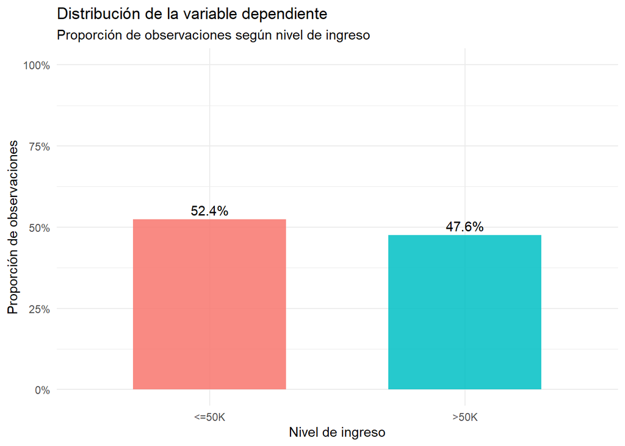

```r
# Grafico la distribución de income para verificar si la variable objetivo está balanceada.
ggplot(balance_income, aes(x = income, y = prop, fill = income)) +
  geom_col(width = 0.6, alpha = 0.85) +
  geom_text(aes(label = porcentaje), vjust = -0.4) +
  scale_y_continuous(
    labels = percent_format(),
    limits = c(0, 1)
  ) +
  labs(
    title = "Distribución de la variable dependiente",
    subtitle = "Proporción de observaciones según nivel de ingreso",
    x = "Nivel de ingreso",
    y = "Proporción de observaciones",
    fill = "Ingreso"
  ) +
  theme_minimal() +
  theme(
    legend.position = "none"
  )
```

**Nota**

**Lectura inicial del balance**

La variable dependiente `income` permite distinguir entre personas con ingresos anuales menores o iguales a **$50.000 dólares** y personas con ingresos superiores a ese umbral. Este análisis inicial es necesario porque la regresión logística modelará la probabilidad de pertenecer a la segunda categoría, es decir, `>50K`. Por lo tanto, antes de avanzar con las variables explicativas, conviene observar si esa categoría aparece en una proporción similar a `<=50K` o si se encuentra menos representada dentro de la base.

# Selección de variables y construcción de la base de modelado

```r
# Creo la base que será utilizada para el análisis exploratorio y los modelos. Mantengo una cantidad reducida de variables para que el modelo sea interpretable.
datos_modelo <- datos |>

  # Recodifico variables categóricas para reducir categorías y facilitar la interpretación.
  mutate(

    # Simplifico marital_status en dos grupos:
    # married incluye los estados civiles "Married".
    # not_married agrupa el resto de las situaciones.
    marital_simple = case_when(
      str_detect(marital_status, "^Married") ~ "married",
      TRUE ~ "not_married"
    ),

    # Simplifico race en White y Other
    race_simple = case_when(
      race == "White" ~ "White",
      TRUE ~ "Other"
    ),

    # Simplifico native_country en United States y Other.
    native_country_simple = case_when(
      native_country == "United-States" ~ "United States",
      TRUE ~ "Other"
    ),

    # Defino los factores y sus categorías de referencia.
    # En income, <=50K ya quedó como referencia en la primera parte.
    # En sex, Female queda como referencia para comparar Male contra Female.
    sex = factor(sex),
    sex = fct_relevel(sex, "Female"),

    marital_simple = factor(
      marital_simple,
      levels = c("not_married", "married")
    ),

    race_simple = factor(
      race_simple,
      levels = c("White", "Other")
    ),

    native_country_simple = factor(
      native_country_simple,
      levels = c("United States", "Other")
    ),

    # Transformo capital_gain y capital_loss con log1p.
    # log1p(x) equivale a log(x + 1), por lo que permite trabajar con valores iguales a cero.
    log_capital_gain = log1p(capital_gain),
    log_capital_loss = log1p(capital_loss)
  ) |>

  # Selecciono únicamente las variables que se van a utilizar.
  select(
    income,
    income_num,
    age,
    education_num,
    sex,
    marital_simple,
    race_simple,
    hours_per_week,
    capital_gain,
    capital_loss,
    log_capital_gain,
    log_capital_loss,
    native_country_simple
  ) |>

  # Elimino observaciones con valores perdidos en las variables seleccionadas.
  filter(
    if_all(everything(), ~ !is.na(.))
  )

# Reviso dimensiones de la base original limpia y de la base de modelado.
tibble(
  base = c("Base limpia inicial", "Base de modelado"),
  observaciones = c(nrow(datos), nrow(datos_modelo)),
  variables = c(ncol(datos), ncol(datos_modelo))
) |>
  knitr::kable(
    caption = "Comparación entre la base limpia inicial y la base utilizada para modelar"
  ) |>
  kable_styling(full_width = FALSE)
```

Comparación entre la base limpia inicial y la base utilizada para modelar

| base | observaciones | variables |
| --- | --- | --- |
| Base limpia inicial | 15766 | 15 |
| Base de modelado | 15766 | 13 |

```r
# Reviso las categorías de referencia de las variables factor. Al ser una regresión logística, la primera categoría será la de referencia.
niveles_referencia <- tibble(
  variable = c(
    "income",
    "sex",
    "marital_simple",
    "race_simple",
    "native_country_simple"
  ),
  categoria_referencia = c(
    levels(datos_modelo$income)[1],
    levels(datos_modelo$sex)[1],
    levels(datos_modelo$marital_simple)[1],
    levels(datos_modelo$race_simple)[1],
    levels(datos_modelo$native_country_simple)[1]
  )
)

niveles_referencia |>
  knitr::kable(
    col.names = c("Variable", "Categoría de referencia"),
    caption = "Categorías de referencia para las variables categóricas"
  ) |>
  kable_styling(full_width = FALSE)
```

Categorías de referencia para las variables categóricas

| Variable | Categoría de referencia |
| --- | --- |
| income | <=50K |
| sex | Female |
| marital_simple | not_married |
| race_simple | White |
| native_country_simple | United States |

```r
# Verifico que no queden valores perdidos en la base de modelado.
datos_modelo |>
  summarise(
    across(
      everything(),
      ~ sum(is.na(.))
    )
  ) |>
  pivot_longer(
    cols = everything(),
    names_to = "variable",
    values_to = "faltantes"
  ) |>
  arrange(desc(faltantes)) |>
  knitr::kable(
    col.names = c("Variable", "Valores perdidos"),
    caption = "Valores perdidos en la base de modelado"
  ) |>
  kable_styling(full_width = FALSE)
```

Valores perdidos en la base de modelado

| Variable | Valores perdidos |
| --- | --- |
| income | 0 |
| income_num | 0 |
| age | 0 |
| education_num | 0 |
| sex | 0 |
| marital_simple | 0 |
| race_simple | 0 |
| hours_per_week | 0 |
| capital_gain | 0 |
| capital_loss | 0 |
| log_capital_gain | 0 |
| log_capital_loss | 0 |
| native_country_simple | 0 |

```r
# Vuelvo a verificar el balance de income después de seleccionar variables y eliminar faltantes.
balance_modelo <- datos_modelo |>
  count(income) |>
  mutate(
    prop = n / sum(n),
    porcentaje = percent(prop, accuracy = 0.1)
  )

balance_modelo |>
  knitr::kable(
    col.names = c("Ingreso", "Cantidad", "Proporción", "Porcentaje"),
    caption = "Distribución de income en la base de modelado"
  ) |>
  kable_styling(full_width = FALSE)
```

Distribución de income en la base de modelado

| Ingreso | Cantidad | Proporción | Porcentaje |
| --- | --- | --- | --- |
| <=50K | 8258 | 0.5237854 | 52.4% |
| >50K | 7508 | 0.4762146 | 47.6% |

# Análisis exploratorio

Antes de ajustar los modelos, conviene mirar cómo se comportan las variables seleccionadas frente a `income`. Esta revisión me sirve para detectar patrones generales, evaluar si conviene realizar alguna transformación y dejar mejor fundamentada la especificación del modelo logístico.

## Variables continuas e ingreso

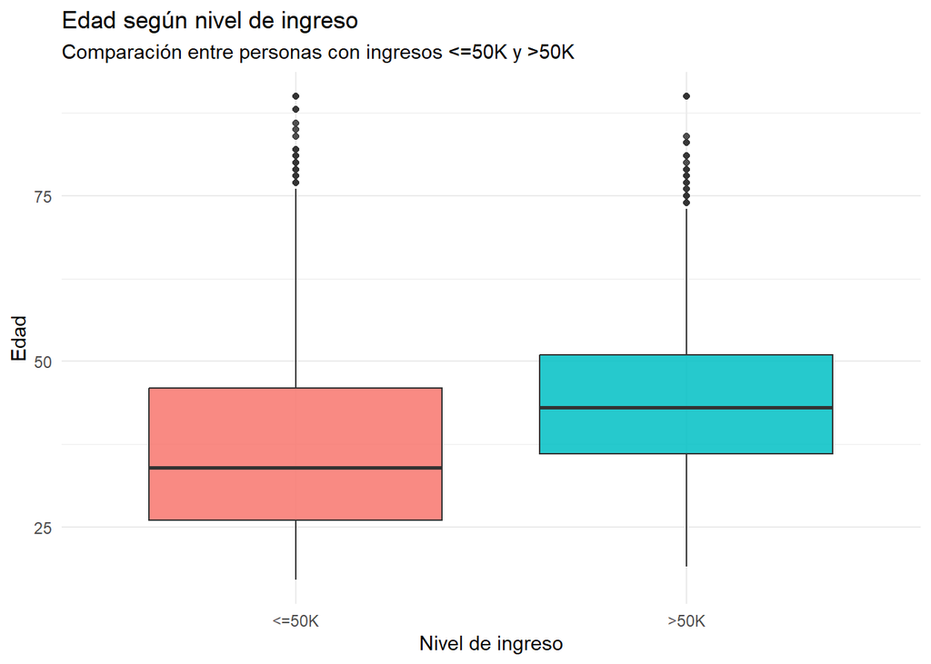

```r
# Comparo la distribución de edad entre los dos grupos de ingreso.
ggplot(datos_modelo, aes(x = income, y = age, fill = income)) +
  geom_boxplot(alpha = 0.85) +
  labs(
    title = "Edad según nivel de ingreso",
    subtitle = "Comparación entre personas con ingresos <=50K y >50K",
    x = "Nivel de ingreso",
    y = "Edad",
    fill = "Ingreso"
  ) +
  theme_minimal() +
  theme(
    legend.position = "none"
  )
```

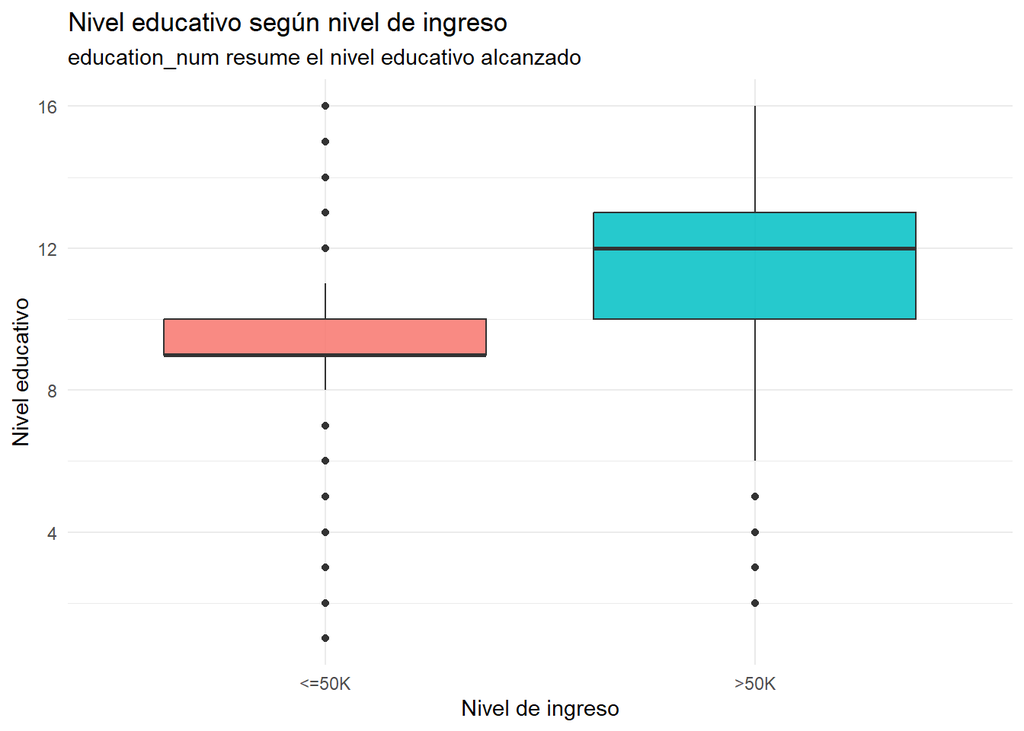

```r
# Comparo la distribución de education_num según nivel de ingreso.
ggplot(datos_modelo, aes(x = income, y = education_num, fill = income)) +
  geom_boxplot(alpha = 0.85) +
  labs(
    title = "Nivel educativo según nivel de ingreso",
    subtitle = "education_num resume el nivel educativo alcanzado",
    x = "Nivel de ingreso",
    y = "Nivel educativo",
    fill = "Ingreso"
  ) +
  theme_minimal() +
  theme(
    legend.position = "none"
  )
```

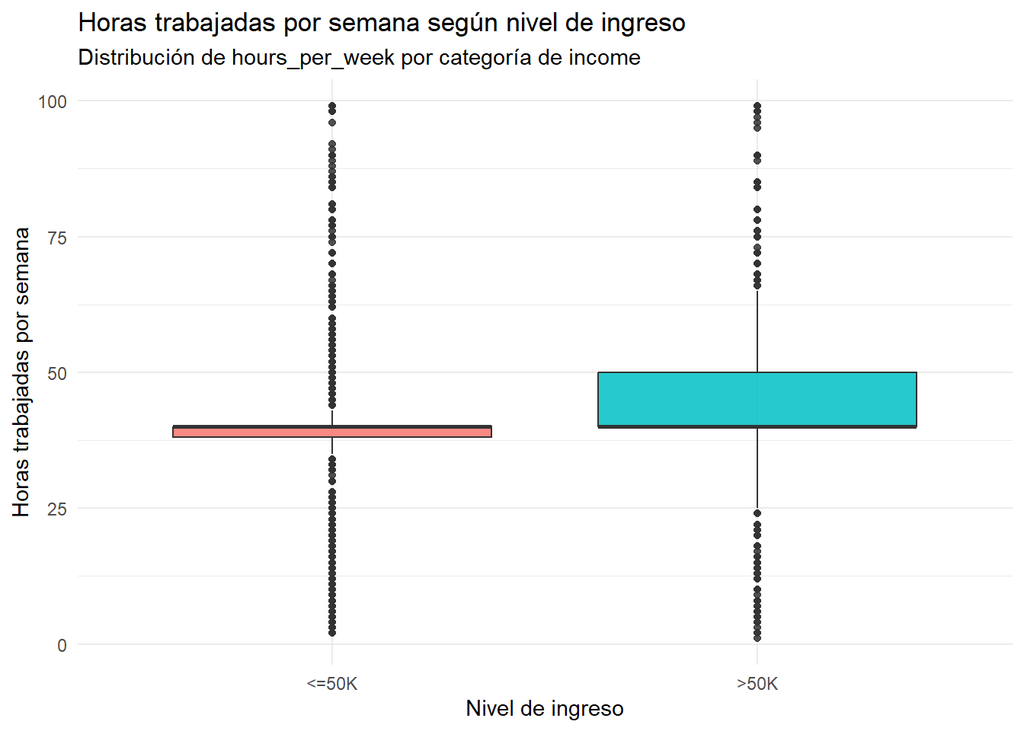

```r
# Comparo la distribución de horas trabajadas por semana según nivel de ingreso.
ggplot(datos_modelo, aes(x = income, y = hours_per_week, fill = income)) +
  geom_boxplot(alpha = 0.85) +
  labs(
    title = "Horas trabajadas por semana según nivel de ingreso",
    subtitle = "Distribución de hours_per_week por categoría de income",
    x = "Nivel de ingreso",
    y = "Horas trabajadas por semana",
    fill = "Ingreso"
  ) +
  theme_minimal() +
  theme(
    legend.position = "none"
  )
```

En conjunto, los gráficos de variables continuas muestran diferencias visibles entre los dos grupos de ingreso. Las personas con ingresos `>50K` tienden a presentar mayores valores de `education_num` y, en general, una distribución algo más alta de horas trabajadas por semana. La edad también muestra una diferencia entre grupos, aunque con mayor superposición. Estas diferencias justifican incluir las tres variables en los modelos, pero no sugieren una transformación adicional para `age`, `education_num` o `hours_per_week`, porque sus escalas siguen siendo interpretables directamente.

## Variables categóricas e ingreso

```r
# Calculo la proporción de personas con ingresos >50K dentro de cada categoría.
proporcion_categoricas <- bind_rows(

  datos_modelo |>
    group_by(sex) |>
    summarise(
      prop_ingreso_alto = mean(income_num),
      n = n(),
      .groups = "drop"
    ) |>
    transmute(
      variable = "Sexo",
      categoria = as.character(sex),
      prop_ingreso_alto,
      n
    ),

  datos_modelo |>
    group_by(marital_simple) |>
    summarise(
      prop_ingreso_alto = mean(income_num),
      n = n(),
      .groups = "drop"
    ) |>
    transmute(
      variable = "Estado civil",
      categoria = as.character(marital_simple),
      prop_ingreso_alto,
      n
    ),

  datos_modelo |>
    group_by(race_simple) |>
    summarise(
      prop_ingreso_alto = mean(income_num),
      n = n(),
      .groups = "drop"
    ) |>
    transmute(
      variable = "Raza",
      categoria = as.character(race_simple),
      prop_ingreso_alto,
      n
    ),

  datos_modelo |>
    group_by(native_country_simple) |>
    summarise(
      prop_ingreso_alto = mean(income_num),
      n = n(),
      .groups = "drop"
    ) |>
    transmute(
      variable = "País de origen",
      categoria = as.character(native_country_simple),
      prop_ingreso_alto,
      n
    )
)

proporcion_categoricas |>
  mutate(
    porcentaje = percent(prop_ingreso_alto, accuracy = 0.1)
  ) |>
  knitr::kable(
    col.names = c("Variable", "Categoría", "Proporción de ingresos >50K", "Cantidad", "Porcentaje"),
    caption = "Proporción de ingresos altos por categoría"
  ) |>
  kable_styling(full_width = FALSE)
```

Proporción de ingresos altos por categoría

| Variable | Categoría | Proporción de ingresos >50K | Cantidad | Porcentaje |
| --- | --- | --- | --- | --- |
| Sexo | Female | 0.2614625 | 4253 | 26.1% |
| Sexo | Male | 0.5555459 | 11513 | 55.6% |
| Estado civil | not_married | 0.1662257 | 6425 | 16.6% |
| Estado civil | married | 0.6894337 | 9341 | 68.9% |
| Raza | White | 0.4935768 | 13856 | 49.4% |
| Raza | Other | 0.3502618 | 1910 | 35.0% |
| País de origen | United States | 0.4834808 | 14468 | 48.3% |
| País de origen | Other | 0.3952234 | 1298 | 39.5% |

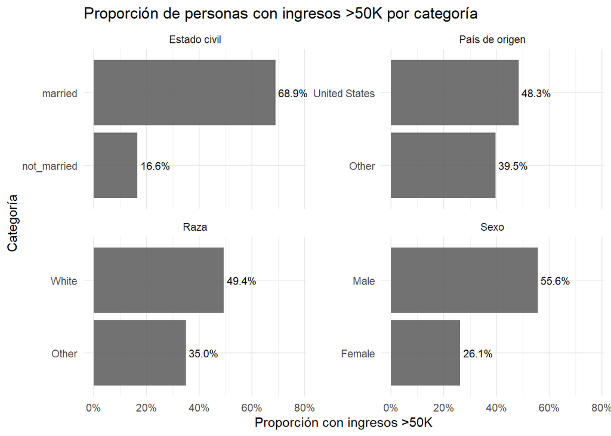

```r
# Grafico la proporción de ingresos altos en cada categoría.
ggplot(
  proporcion_categoricas,
  aes(x = reorder(categoria, prop_ingreso_alto), y = prop_ingreso_alto)
) +
  geom_col(alpha = 0.85) +
  geom_text(
    aes(label = percent(prop_ingreso_alto, accuracy = 0.1)),
    hjust = -0.1,
    size = 3
  ) +
  coord_flip() +
  facet_wrap(~ variable, scales = "free_y") +
  scale_y_continuous(
    labels = percent_format(),
    limits = c(0, max(proporcion_categoricas$prop_ingreso_alto) + 0.08)
  ) +
  labs(
    title = "Proporción de personas con ingresos >50K por categoría",
    x = "Categoría",
    y = "Proporción con ingresos >50K"
  ) +
  theme_minimal()
```

# Decisiones de transformación

Al revisar `capital_gain` y `capital_loss`, vemos que la mayoría de los casos queda en cero y solo una parte menor registra valores positivos, algunos de ellos muy altos. Por eso, trabajar con la escala original puede hacer que esos valores extremos pesen demasiado en el análisis. Para evitarlo, uso `log1p()`, que es equivalente a `log(x + 1)`, lo que me permite transformar la variable sin perder las observaciones que tienen valor cero.

```r
# Resumo las variables de capital antes y después de la transformación logarítmica.
datos_modelo |>
  summarise(
    capital_gain_min = min(capital_gain),
    capital_gain_media = mean(capital_gain),
    capital_gain_mediana = median(capital_gain),
    capital_gain_max = max(capital_gain),
    capital_loss_min = min(capital_loss),
    capital_loss_media = mean(capital_loss),
    capital_loss_mediana = median(capital_loss),
    capital_loss_max = max(capital_loss)
  ) |>
  pivot_longer(
    cols = everything(),
    names_to = "estadistico",
    values_to = "valor"
  ) |>
  knitr::kable(
    caption = "Resumen de capital_gain y capital_loss antes de la transformación"
  ) |>
  kable_styling(full_width = FALSE)
```

Resumen de capital_gain y capital_loss antes de la transformación

| estadistico | valor |
| --- | --- |
| capital_gain_min | 0.0000 |
| capital_gain_media | 1951.7372 |
| capital_gain_mediana | 0.0000 |
| capital_gain_max | 99999.0000 |
| capital_loss_min | 0.0000 |
| capital_loss_media | 119.8995 |
| capital_loss_mediana | 0.0000 |
| capital_loss_max | 4356.0000 |

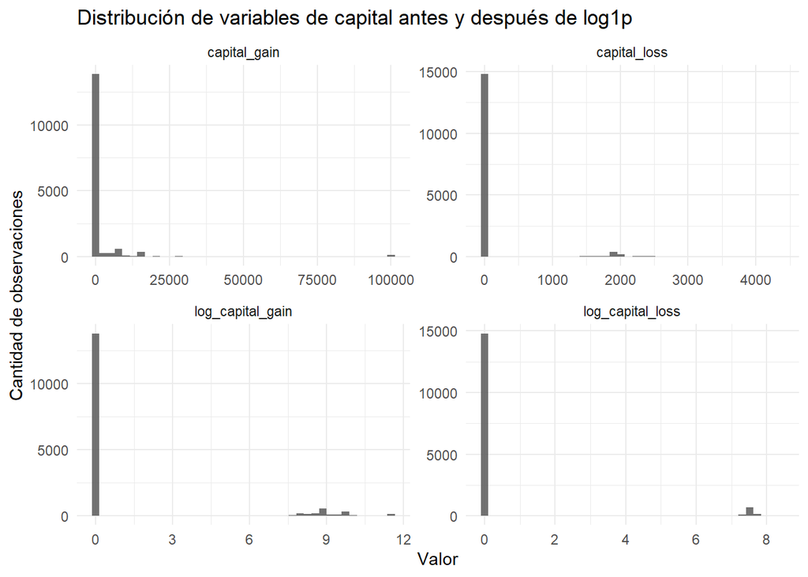

```r
# Paso las variables de capital a formato largo para comparar distribuciones.
capital_largo <- datos_modelo |>
  select(
    capital_gain,
    capital_loss,
    log_capital_gain,
    log_capital_loss
  ) |>
  pivot_longer(
    cols = everything(),
    names_to = "variable",
    values_to = "valor"
  )

# Grafico la distribución de las variables originales y transformadas.
ggplot(capital_largo, aes(x = valor)) +
  geom_histogram(bins = 40, alpha = 0.85) +
  facet_wrap(~ variable, scales = "free") +
  labs(
    title = "Distribución de variables de capital antes y después de log1p",
    x = "Valor",
    y = "Cantidad de observaciones"
  ) +
  theme_minimal()
```

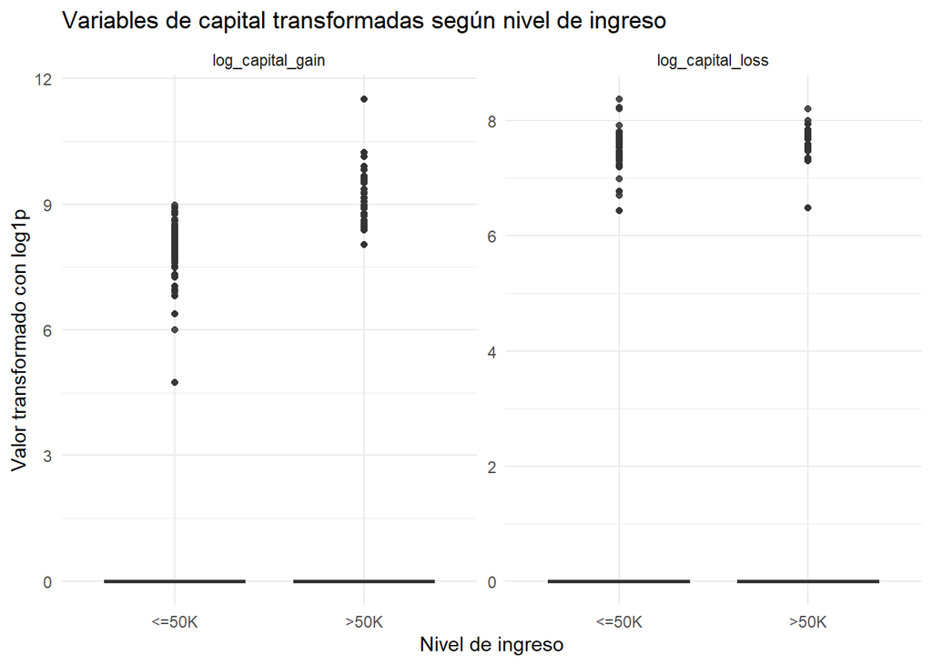

```r
# Comparo las variables transformadas según nivel de ingreso.
datos_modelo |>
  select(income, log_capital_gain, log_capital_loss) |>
  pivot_longer(
    cols = c(log_capital_gain, log_capital_loss),
    names_to = "variable",
    values_to = "valor"
  ) |>
  ggplot(aes(x = income, y = valor, fill = income)) +
  geom_boxplot(alpha = 0.85) +
  facet_wrap(~ variable, scales = "free_y") +
  labs(
    title = "Variables de capital transformadas según nivel de ingreso",
    x = "Nivel de ingreso",
    y = "Valor transformado con log1p",
    fill = "Ingreso"
  ) +
  theme_minimal() +
  theme(
    legend.position = "none"
  )
```

**Nota**

**Sobre la transformación**

Como `capital_gain` y `capital_loss` tienen muchos valores en cero y algunos valores positivos muy altos, se usa `log1p()` para reducir el peso de los extremos sin perder esas observaciones. Esta función equivale a `log(x + 1)`, por lo que permite trabajar correctamente con valores iguales a cero.

# Término de interacción propuesto

Además del modelo base, incluyo una interacción entre `sex` y `hours_per_week` para evaluar si la relación entre horas trabajadas por semana e ingresos altos se comporta igual en hombres y mujeres. La hipótesis detrás de esta decisión es que una mayor cantidad de horas trabajadas no necesariamente se traduce de la misma manera en la probabilidad de superar los **$50.000 dólares** anuales, porque pueden existir diferencias en inserción laboral, tipo de ocupación, remuneración horaria y acceso a puestos mejor pagos.

Antes de incorporar esa interacción al modelo, observo visualmente la distribución de `hours_per_week` según `income`, separando el análisis por sexo. Esta visualización permite verificar si la distancia entre ingresos bajos e ingresos altos en las horas trabajadas presenta patrones distintos entre mujeres y varones.

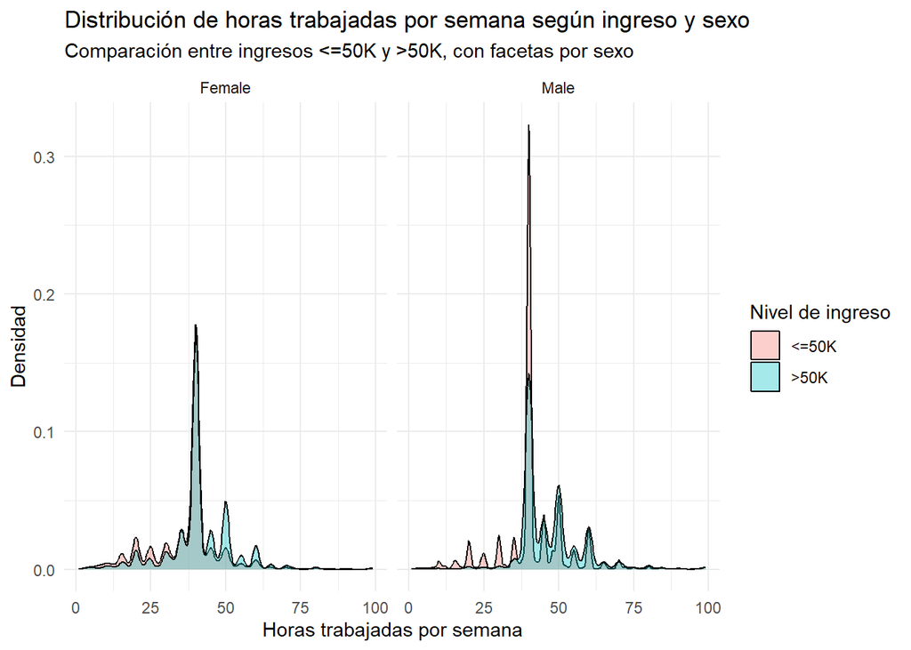

```r
# Grafico la distribución de hours_per_week por nivel de ingreso,
# separando la comparación entre mujeres y varones.
ggplot(datos_modelo, aes(x = hours_per_week, fill = income)) +
  geom_density(alpha = 0.35) +
  facet_wrap(~ sex) +
  labs(
    title = "Distribución de horas trabajadas por semana según ingreso y sexo",
    subtitle = "Comparación entre ingresos <=50K y >50K, con facetas por sexo",
    x = "Horas trabajadas por semana",
    y = "Densidad",
    fill = "Nivel de ingreso"
  ) +
  theme_minimal()
```

El gráfico muestra que la distribución de `hours_per_week` no es idéntica entre los grupos de ingreso ni entre sexos. En ambos paneles, las personas con ingresos superiores a **$50.000 dólares** tienden a concentrarse en valores relativamente más altos de horas trabajadas. Sin embargo, la comparación por sexo permite observar que esa diferencia no necesariamente tiene la misma forma en mujeres y varones. Por eso, la interacción entre `sex` y `hours_per_week` queda justificada tanto teóricamente como a partir de la exploración visual.

# Ajuste de modelos de regresión logística

La variable dependiente es `income`. Como `<=50K` quedó definida como categoría de referencia y `>50K` como segunda categoría del factor, los modelos estiman la probabilidad de que una persona pertenezca al grupo de ingresos superiores a **$50.000 dólares** anuales.

## Modelo 1: modelo base sin interacción

```r
# Ajusto un modelo logístico base sin interacción.
modelo_1 <- glm(
  income ~ age +
    education_num +
    sex +
    marital_simple +
    race_simple +
    hours_per_week +
    log_capital_gain +
    log_capital_loss +
    native_country_simple,
  data = datos_modelo,
  family = binomial(link = "logit")
)

# Reviso el resumen del modelo base.
summary(modelo_1)
```

```
Call:
glm(formula = income ~ age + education_num + sex + marital_simple +
    race_simple + hours_per_week + log_capital_gain + log_capital_loss +
    native_country_simple, family = binomial(link = "logit"),
    data = datos_modelo)

Coefficients:
                            Estimate Std. Error z value Pr(>|z|)
(Intercept)                -8.834451   0.178305 -49.547  < 2e-16 ***
age                         0.034423   0.001889  18.227  < 2e-16 ***
education_num               0.376087   0.009887  38.039  < 2e-16 ***
sexMale                     0.208011   0.056331   3.693 0.000222 ***
marital_simplemarried       2.351315   0.052855  44.486  < 2e-16 ***
race_simpleOther           -0.179815   0.070565  -2.548 0.010827 *
hours_per_week              0.034058   0.002115  16.104  < 2e-16 ***
log_capital_gain            0.206548   0.008752  23.600  < 2e-16 ***
log_capital_loss            0.155986   0.012810  12.177  < 2e-16 ***
native_country_simpleOther -0.226846   0.084883  -2.672 0.007530 **
---
Signif. codes:  0 '***' 0.001 '**' 0.01 '*' 0.05 '.' 0.1 ' ' 1

(Dispersion parameter for binomial family taken to be 1)

    Null deviance: 21821  on 15765  degrees of freedom
Residual deviance: 13372  on 15756  degrees of freedom
AIC: 13392

Number of Fisher Scoring iterations: 5
```

## Modelo 2: modelo con interacción

```r
# Ajusto un segundo modelo logístico con los mismos predictores del modelo base,
# pero incorporando una interacción entre sex y hours_per_week.
modelo_2 <- glm(
  income ~ age +
    education_num +
    sex * hours_per_week +
    marital_simple +
    race_simple +
    log_capital_gain +
    log_capital_loss +
    native_country_simple,
  data = datos_modelo,
  family = binomial(link = "logit")
)

# Reviso el resumen del modelo interactivo.
summary(modelo_2)
```

```
Call:
glm(formula = income ~ age + education_num + sex * hours_per_week +
    marital_simple + race_simple + log_capital_gain + log_capital_loss +
    native_country_simple, family = binomial(link = "logit"),
    data = datos_modelo)

Coefficients:
                            Estimate Std. Error z value Pr(>|z|)
(Intercept)                -8.601971   0.223671 -38.458  < 2e-16 ***
age                         0.034510   0.001887  18.285  < 2e-16 ***
education_num               0.376774   0.009902  38.051  < 2e-16 ***
sexMale                    -0.123386   0.203239  -0.607  0.54379
hours_per_week              0.027988   0.004147   6.749 1.49e-11 ***
marital_simplemarried       2.346620   0.052893  44.365  < 2e-16 ***
race_simpleOther           -0.177548   0.070563  -2.516  0.01186 *
log_capital_gain            0.206602   0.008749  23.614  < 2e-16 ***
log_capital_loss            0.155736   0.012810  12.158  < 2e-16 ***
native_country_simpleOther -0.226790   0.084887  -2.672  0.00755 **
sexMale:hours_per_week      0.008147   0.004804   1.696  0.08995 .
---
Signif. codes:  0 '***' 0.001 '**' 0.01 '*' 0.05 '.' 0.1 ' ' 1

(Dispersion parameter for binomial family taken to be 1)

    Null deviance: 21821  on 15765  degrees of freedom
Residual deviance: 13369  on 15755  degrees of freedom
AIC: 13391

Number of Fisher Scoring iterations: 5
```

```r
# Presento una primera tabla comparativa con ambos modelos.
modelsummary(
  list(
    "Modelo 1: base" = modelo_1,
    "Modelo 2: interacción" = modelo_2
  ),
  estimate = "{estimate}",
  statistic = "({std.error})",
  stars = TRUE,
  output = "kableExtra",
  gof_omit = "IC|Log|Adj|RMSE"
) |>
  kable_styling(full_width = FALSE)
```

|  | Modelo 1: base | &nbsp;Modelo 2: interacción |
| --- | --- | --- |
| (Intercept) | -8.834 | -8.602 |
|  | (0.178) | (0.224) |
| age | 0.034 | 0.035 |
|  | (0.002) | (0.002) |
| education_num | 0.376 | 0.377 |
|  | (0.010) | (0.010) |
| sexMale | 0.208 | -0.123 |
|  | (0.056) | (0.203) |
| marital_simplemarried | 2.351 | 2.347 |
|  | (0.053) | (0.053) |
| race_simpleOther | -0.180 | -0.178 |
|  | (0.071) | (0.071) |
| hours_per_week | 0.034 | 0.028 |
|  | (0.002) | (0.004) |
| log_capital_gain | 0.207 | 0.207 |
|  | (0.009) | (0.009) |
| log_capital_loss | 0.156 | 0.156 |
|  | (0.013) | (0.013) |
| native_country_simpleOther | -0.227 | -0.227 |
|  | (0.085) | (0.085) |
| sexMale × hours_per_week |  | 0.008 |
|  |  | (0.005) |
| Num.Obs. | 15766 | 15766 |
| F | 454.415 | 409.534 |

+ p < 0.1, * p < 0.05, ** p < 0.01, *** p < 0.001

El **Modelo 1** estima la asociación entre cada predictor y la probabilidad de tener ingresos superiores a **$50.000 dólares**, manteniendo constantes las demás variables. El **Modelo 2** conserva los mismos predictores, pero agrega la interacción entre `sex` y `hours_per_week`. Por lo tanto, permite evaluar si la relación entre horas trabajadas e ingresos altos varía según el sexo.

# Interpretación de resultados y efectos marginales

A partir de los dos modelos ajustados, la interpretación se concentra en el **Modelo 2**, porque es el que incorpora la interacción planteada en la hipótesis. Para facilitar la lectura, primero presento los efectos marginales promedio y luego los odds ratios.

## Efectos marginales promedio

```r
# Calculo los efectos marginales promedio del Modelo 2.
ame_modelo_2 <- avg_slopes(
  modelo_2,
  type = "response"
)

ame_tabla <- as_tibble(ame_modelo_2)

# En algunas versiones del paquete, contrast no aparece para todas las variables.
if (!"contrast" %in% names(ame_tabla)) {
  ame_tabla <- ame_tabla |>
    mutate(contrast = NA_character_)
}

ame_tabla <- ame_tabla |>
  mutate(
    variable = case_when(
      term == "age" ~ "Edad",
      term == "education_num" ~ "Nivel educativo",
      term == "sex" ~ "Sexo",
      term == "marital_simple" ~ "Estado civil",
      term == "race_simple" ~ "Raza",
      term == "hours_per_week" ~ "Horas por semana",
      term == "log_capital_gain" ~ "Capital gain, log",
      term == "log_capital_loss" ~ "Capital loss, log",
      term == "native_country_simple" ~ "País de origen",
      TRUE ~ term
    ),
    comparacion = if_else(
      is.na(contrast),
      "Cambio de una unidad",
      contrast
    )
  ) |>
  transmute(
    variable,
    comparacion,
    efecto_pp = round(estimate * 100, 3),
    error_estandar = round(std.error * 100, 3),
    ic_95_inferior = round(conf.low * 100, 3),
    ic_95_superior = round(conf.high * 100, 3),
    p_valor = format.pval(p.value, digits = 3, eps = 0.001)
  )

ame_tabla |>
  knitr::kable(
    col.names = c(
      "Variable",
      "Comparación",
      "Efecto en puntos porcentuales",
      "Error estándar",
      "IC 95% inferior",
      "IC 95% superior",
      "p valor"
    ),
    caption = "Efectos marginales promedio del Modelo 2"
  ) |>
  kable_styling(full_width = FALSE)
```

Efectos marginales promedio del Modelo 2

| Variable | Comparación | Efecto en puntos porcentuales | Error estándar | IC 95% inferior | IC 95% superior | p valor |
| --- | --- | --- | --- | --- | --- | --- |
| Edad | dY/dX | 0.472 | 0.025 | 0.423 | 0.521 | < 0.001 |
| Nivel educativo | dY/dX | 5.156 | 0.112 | 4.936 | 5.377 | < 0.001 |
| Horas por semana | dY/dX | 0.469 | 0.028 | 0.413 | 0.524 | < 0.001 |
| Capital gain, log | dY/dX | 2.828 | 0.113 | 2.607 | 3.048 | < 0.001 |
| Capital loss, log | dY/dX | 2.131 | 0.173 | 1.793 | 2.470 | < 0.001 |
| Estado civil | married - not_married | 38.072 | 0.778 | 36.547 | 39.596 | < 0.001 |
| País de origen | Other - United States | -3.110 | 1.165 | -5.392 | -0.827 | 0.00758 |
| Raza | Other - White | -2.438 | 0.971 | -4.342 | -0.534 | 0.01207 |
| Sexo | Male - Female | 3.193 | 0.817 | 1.592 | 4.794 | < 0.001 |

Los efectos marginales promedio permiten interpretar los resultados en términos de cambios en probabilidad. En las variables continuas, el efecto indica cuánto cambia, en promedio, la probabilidad de tener ingresos superiores a **$50.000 dólares** ante una unidad adicional de la variable. En las variables categóricas, el efecto expresa la diferencia promedio respecto de la categoría de referencia.

## Efecto marginal de las horas trabajadas según sexo

```r
# Como el Modelo 2 incluye una interacción entre sex y hours_per_week,
# calculo el efecto marginal promedio de hours_per_week por separado para cada sexo.
efectos_hours_sex <- avg_slopes(
  modelo_2,
  variables = "hours_per_week",
  by = "sex",
  type = "response"
) |>
  as_tibble() |>
  transmute(
    sexo = sex,
    efecto_pp = round(estimate * 100, 3),
    error_estandar = round(std.error * 100, 3),
    ic_95_inferior = round(conf.low * 100, 3),
    ic_95_superior = round(conf.high * 100, 3),
    p_valor = format.pval(p.value, digits = 3, eps = 0.001)
  )

efectos_hours_sex |>
  knitr::kable(
    col.names = c(
      "Sexo",
      "Efecto de una hora adicional en p.p.",
      "Error estándar",
      "IC 95% inferior",
      "IC 95% superior",
      "p valor"
    ),
    caption = "Efecto marginal promedio de hours_per_week según sexo"
  ) |>
  kable_styling(full_width = FALSE)
```

Efecto marginal promedio de hours_per_week según sexo

| Sexo | Efecto de una hora adicional en p.p. | Error estándar | IC 95% inferior | IC 95% superior | p valor |
| --- | --- | --- | --- | --- | --- |
| Female | 0.329 | 0.048 | 0.235 | 0.423 | <0.001 |
| Male | 0.520 | 0.034 | 0.453 | 0.587 | <0.001 |

Esta tabla permite leer la interacción de manera más directa. Si el efecto marginal de `hours_per_week` difiere entre mujeres y varones, eso indica que una hora adicional de trabajo semanal no se asocia con el mismo cambio promedio en la probabilidad de pertenecer al grupo `>50K` para ambos sexos.

## Odds ratios del Modelo 2

```r
# Paso los coeficientes del Modelo 2 a odds ratios.
odds_ratios <- tidy(modelo_2) |>
  filter(term != "(Intercept)") |>
  mutate(
    odds_ratio = exp(estimate),
    conf_80_low = exp(estimate - qnorm(0.90) * std.error),
    conf_80_high = exp(estimate + qnorm(0.90) * std.error),
    conf_95_low = exp(estimate - qnorm(0.975) * std.error),
    conf_95_high = exp(estimate + qnorm(0.975) * std.error),
    conf_99_low = exp(estimate - qnorm(0.995) * std.error),
    conf_99_high = exp(estimate + qnorm(0.995) * std.error),
    termino_limpio = case_when(
      term == "age" ~ "Edad",
      term == "education_num" ~ "Nivel educativo",
      term == "sexMale" ~ "Sexo: Male",
      term == "marital_simplemarried" ~ "Estado civil: married",
      term == "race_simpleOther" ~ "Raza: Other",
      term == "hours_per_week" ~ "Horas por semana",
      term == "log_capital_gain" ~ "Capital gain, log",
      term == "log_capital_loss" ~ "Capital loss, log",
      term == "native_country_simpleOther" ~ "País de origen: Other",
      str_detect(term, "sexMale") & str_detect(term, "hours_per_week") ~ "Interacción: Male y horas",
      TRUE ~ term
    )
  )

odds_ratios |>
  transmute(
    variable = termino_limpio,
    odds_ratio = round(odds_ratio, 3),
    ic_95_inferior = round(conf_95_low, 3),
    ic_95_superior = round(conf_95_high, 3),
    p_valor = format.pval(p.value, digits = 3, eps = 0.001)
  ) |>
  knitr::kable(
    col.names = c(
      "Variable",
      "Odds ratio",
      "IC 95% inferior",
      "IC 95% superior",
      "p valor"
    ),
    caption = "Odds ratios del Modelo 2"
  ) |>
  kable_styling(full_width = FALSE)
```

Odds ratios del Modelo 2

| Variable | Odds ratio | IC 95% inferior | IC 95% superior | p valor |
| --- | --- | --- | --- | --- |
| Edad | 1.035 | 1.031 | 1.039 | < 0.001 |
| Nivel educativo | 1.458 | 1.430 | 1.486 | < 0.001 |
| Sexo: Male | 0.884 | 0.593 | 1.316 | 0.54379 |
| Horas por semana | 1.028 | 1.020 | 1.037 | < 0.001 |
| Estado civil: married | 10.450 | 9.421 | 11.592 | < 0.001 |
| Raza: Other | 0.837 | 0.729 | 0.962 | 0.01186 |
| Capital gain, log | 1.229 | 1.209 | 1.251 | < 0.001 |
| Capital loss, log | 1.169 | 1.140 | 1.198 | < 0.001 |
| País de origen: Other | 0.797 | 0.675 | 0.941 | 0.00755 |
| Interacción: Male y horas | 1.008 | 0.999 | 1.018 | 0.08995 |

Los odds ratios permiten leer los coeficientes del modelo en términos de chances. Un valor superior a 1 indica mayores chances de tener ingresos superiores a **$50.000 dólares**, manteniendo constantes las demás variables del modelo. Un valor inferior a 1 indica menores chances. En cambio, un valor cercano a 1 sugiere que la variable modifica poco las chances estimadas.

## Forest plot de odds ratios

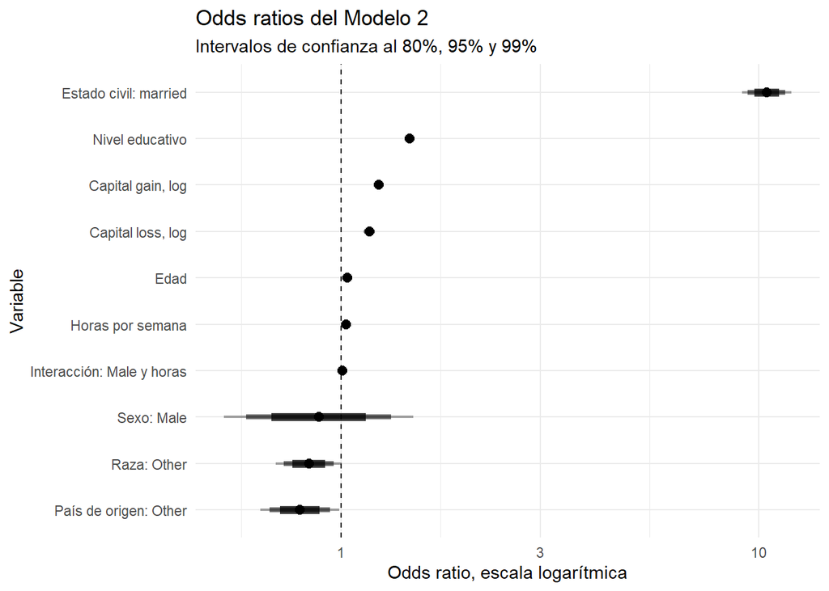

```r
# Ordeno los términos para que el gráfico sea más claro.
odds_ratios_plot <- odds_ratios |>
  mutate(
    termino_limpio = fct_reorder(termino_limpio, odds_ratio)
  )

# Grafico los odds ratios con intervalos de confianza al 80%, 95% y 99%.
ggplot(odds_ratios_plot, aes(y = termino_limpio)) +
  geom_vline(
    xintercept = 1,
    linetype = "dashed"
  ) +
  geom_segment(
    aes(
      x = conf_99_low,
      xend = conf_99_high,
      yend = termino_limpio
    ),
    linewidth = 0.8,
    alpha = 0.35
  ) +
  geom_segment(
    aes(
      x = conf_95_low,
      xend = conf_95_high,
      yend = termino_limpio
    ),
    linewidth = 1.5,
    alpha = 0.55
  ) +
  geom_segment(
    aes(
      x = conf_80_low,
      xend = conf_80_high,
      yend = termino_limpio
    ),
    linewidth = 2.3,
    alpha = 0.75
  ) +
  geom_point(
    aes(x = odds_ratio),
    size = 2.5
  ) +
  scale_x_log10() +
  labs(
    title = "Odds ratios del Modelo 2",
    subtitle = "Intervalos de confianza al 80%, 95% y 99%",
    x = "Odds ratio, escala logarítmica",
    y = "Variable"
  ) +
  theme_minimal()
```

El forest plot resume visualmente la dirección y la magnitud de las asociaciones estimadas en el Modelo 2. La línea vertical en 1 representa ausencia de cambio en las chances. Los puntos ubicados a la derecha de esa línea indican variables asociadas con mayores chances de tener ingresos altos; los puntos ubicados a la izquierda indican menores chances. Además, los intervalos que cruzan la línea de 1 muestran efectos menos precisos o menos claros desde el punto de vista estadístico.

## Variables significativas

```r
# Ordeno las variables significativas al 5%.
variables_significativas <- odds_ratios |>
  filter(p.value < 0.05) |>
  mutate(
    direccion = if_else(
      odds_ratio > 1,
      "Aumenta las chances",
      "Reduce las chances"
    )
  ) |>
  transmute(
    variable = termino_limpio,
    direccion,
    odds_ratio = round(odds_ratio, 3),
    p_valor = format.pval(p.value, digits = 3, eps = 0.001)
  )

variables_significativas |>
  knitr::kable(
    col.names = c(
      "Variable",
      "Dirección",
      "Odds ratio",
      "p valor"
    ),
    caption = "Variables significativas del Modelo 2 al 5%"
  ) |>
  kable_styling(full_width = FALSE)
```

Variables significativas del Modelo 2 al 5%

| Variable | Dirección | Odds ratio | p valor |
| --- | --- | --- | --- |
| Edad | Aumenta las chances | 1.035 | < 0.001 |
| Nivel educativo | Aumenta las chances | 1.458 | < 0.001 |
| Horas por semana | Aumenta las chances | 1.028 | < 0.001 |
| Estado civil: married | Aumenta las chances | 10.450 | < 0.001 |
| Raza: Other | Reduce las chances | 0.837 | 0.01186 |
| Capital gain, log | Aumenta las chances | 1.229 | < 0.001 |
| Capital loss, log | Aumenta las chances | 1.169 | < 0.001 |
| País de origen: Other | Reduce las chances | 0.797 | 0.00755 |

Las variables significativas al 5% son las que muestran una asociación más clara con la probabilidad de tener ingresos altos dentro de este modelo. En conjunto, los resultados sugieren que la probabilidad de superar los **$50.000 dólares** anuales no se explica por una sola dimensión, sino por una combinación de educación, edad, estado civil, horas trabajadas, variables de capital y características sociodemográficas.

## Interpretación de la interacción

```r
# Separo el término de interacción para leerlo con más claridad.
interaccion <- odds_ratios |>
  filter(str_detect(term, "sexMale") & str_detect(term, "hours_per_week")) |>
  transmute(
    termino = termino_limpio,
    odds_ratio = odds_ratio,
    ic_95_inferior = conf_95_low,
    ic_95_superior = conf_95_high,
    p_value = p.value
  )

interaccion |>
  mutate(
    odds_ratio = round(odds_ratio, 3),
    ic_95_inferior = round(ic_95_inferior, 3),
    ic_95_superior = round(ic_95_superior, 3),
    p_valor = format.pval(p_value, digits = 3, eps = 0.001)
  ) |>
  select(-p_value) |>
  knitr::kable(
    col.names = c(
      "Término",
      "Odds ratio",
      "IC 95% inferior",
      "IC 95% superior",
      "p valor"
    ),
    caption = "Término de interacción del Modelo 2"
  ) |>
  kable_styling(full_width = FALSE)
```

Término de interacción del Modelo 2

| Término | Odds ratio | IC 95% inferior | IC 95% superior | p valor |
| --- | --- | --- | --- | --- |
| Interacción: Male y horas | 1.008 | 0.999 | 1.018 | 0.09 |

```r
interaccion_or <- interaccion |> pull(odds_ratio) |> first()
interaccion_p <- interaccion |> pull(p_value) |> first()
```

La interacción entre `sexMale` y `hours_per_week` tiene un odds ratio de 1.008 y un p valor de 0.09. Esto indica si la asociación entre horas trabajadas e ingresos altos cambia para los varones respecto de las mujeres, que son la categoría de referencia. Si el odds ratio de la interacción es mayor a 1, la pendiente de `hours_per_week` es más positiva para los varones; si es menor a 1, es menos positiva. De todos modos, la interpretación sustantiva debe considerar también el p valor y la magnitud del efecto, porque una diferencia muy pequeña puede no implicar una mejora relevante del modelo.

# Comparación global de modelos

```r
# Comparo los dos modelos con glance().
comparacion_modelos <- bind_rows(
  glance(modelo_1) |>
    mutate(modelo = "Modelo 1: base"),
  glance(modelo_2) |>
    mutate(modelo = "Modelo 2: interacción")
) |>
  mutate(
    pseudo_r2 = 1 - deviance / null.deviance
  ) |>
  select(
    modelo,
    nobs,
    AIC,
    BIC,
    deviance,
    null.deviance,
    pseudo_r2
  )

comparacion_modelos_tabla <- comparacion_modelos |>
  mutate(
    AIC = round(AIC, 3),
    BIC = round(BIC, 3),
    deviance = round(deviance, 3),
    null.deviance = round(null.deviance, 3),
    pseudo_r2 = round(pseudo_r2, 4)
  )

comparacion_modelos_tabla |>
  knitr::kable(
    col.names = c(
      "Modelo",
      "Observaciones",
      "AIC",
      "BIC",
      "Deviance",
      "Null deviance",
      "Pseudo R2"
    ),
    caption = "Comparación global entre modelos"
  ) |>
  kable_styling(full_width = FALSE)
```

Comparación global entre modelos

| Modelo | Observaciones | AIC | BIC | Deviance | Null deviance | Pseudo R2 |
| --- | --- | --- | --- | --- | --- | --- |
| Modelo 1: base | 15766 | 13392.06 | 13468.72 | 13372.06 | 21820.62 | 0.3872 |
| Modelo 2: interacción | 15766 | 13391.20 | 13475.52 | 13369.20 | 21820.62 | 0.3873 |

```r
# Guardo algunos valores para mencionarlos en la conclusión.
aic_m1 <- comparacion_modelos |>
  filter(modelo == "Modelo 1: base") |>
  pull(AIC)

aic_m2 <- comparacion_modelos |>
  filter(modelo == "Modelo 2: interacción") |>
  pull(AIC)

pseudo_m1 <- comparacion_modelos |>
  filter(modelo == "Modelo 1: base") |>
  pull(pseudo_r2)

pseudo_m2 <- comparacion_modelos |>
  filter(modelo == "Modelo 2: interacción") |>
  pull(pseudo_r2)

delta_aic <- aic_m2 - aic_m1
delta_pseudo <- pseudo_m2 - pseudo_m1
```

En términos generales, si el Modelo 2 reduce el AIC y aumenta el pseudo R2, la interacción mejora el ajuste global. En cambio, si el AIC aumenta o el pseudo R2 cambia de manera muy pequeña, la interacción no aporta una mejora sustantiva. En este caso, la decisión debe considerar tanto la comparación global como la interpretación del término interactivo: una interacción teóricamente razonable puede ser útil para explorar la hipótesis, pero no necesariamente mejora el modelo de manera relevante.

# Conclusión

El análisis permite identificar qué características sociodemográficas y laborales se asocian con la probabilidad de tener ingresos superiores a **$50.000 dólares** anuales. Los resultados muestran que variables como el nivel educativo, la edad, el estado civil, las horas trabajadas por semana y las variables de capital se vinculan con diferencias importantes en la probabilidad estimada de pertenecer al grupo de ingresos altos.

La transformación de `capital_gain` y `capital_loss` mediante `log1p()` fue adecuada porque ambas variables presentan muchos valores en cero y algunos valores positivos muy altos. De esta forma, se redujo el peso de los valores extremos sin eliminar observaciones.

La interacción entre `sex` y `hours_per_week` tenía sentido teórico y quedó respaldada por una visualización bivariada previa, en la que se comparó la distribución de horas trabajadas por nivel de ingreso y sexo. Sin embargo, la comparación final entre modelos permite evaluar si esa interacción realmente mejora el ajuste global. Si la mejora en AIC y pseudo R2 es mínima, el Modelo 1 resulta más parsimonioso; si el Modelo 2 mejora ambos indicadores, entonces la interacción aporta información relevante.

En cualquier caso, los resultados deben interpretarse como asociaciones estadísticas y no como efectos causales. El modelo permite describir patrones y estimar relaciones condicionales entre variables, pero no utiliza una estrategia de identificación causal ni un diseño experimental.